# Homework #6

Elaine OldBear

4/16/2019

## Top dogs

In this homework, you will try to reproduce the fantastic infographic for [top dogs](https://informationisbeautiful.net/visualizations/best-in-show-whats-the-top-data-dog/), originally produced by David McCandless. The raw data can be found [here](https://docs.google.com/spreadsheets/d/1l_HfF5EaN-QgnLc2UYdCc7L2CVrk0p3VdGB1godOyhk/edit#gid=10). You can download this file by File – Download As – Microsoft Excel (.xlsx).

**Submission instructions**: Create a folder named `ds202_hw6`, and name the RMarkDown file including your solutions `hw6.Rmd` under this folder. For the submission, create a GitHub repository named `ds202_hw6` under your GitHub account, and push both `hw6.Rmd` and the knitted `hw6.html` before the deadline. I will assume you use the same GitHub username as for your HW5 submission. The latest version of your homework appearing on GitHub before the deadline is graded. *It is crucial to follow the exact folder structure and file names*, so that your homework can be reproduced and graded by an automated script. This homework is **due on April 25** before class.

1. Import the data and clean appropriately. To read in the data, you can use `readxl::read_xlsx('fileNameHere', sheet='sheetNameHere')`. Required data are in the sheets `Best in show` and `Best in show full sheet`. Take extra care on the column names and the first few rows of the data frame after read in.
2. Create a graphics similar to the [top dogs](https://informationisbeautiful.net/visualizations/best-in-show-whats-the-top-data-dog/) figure. Your figure need to display the following information with appropriate plotting elements:
- breed of dog
- type of dog (work, toy, etc.)
- size of dog
- data score
- popularity
- intelligence of the dog
- appropriate legends & explanation

Hints and Notes:

- The breed of dog can be displayed without the silhouttes (text only is fine)
- Avoid (too much) overlap!
- Choose a good color scheme.
- Your submission is supposed to be fully reproducible, i.e. the TA and I will ‘knit’ your submission in RStudio.

```r
library(ggplot2)
library(dplyr)
library(tidyverse)
library(readxl)
library(ggrepel)
library(tidyr)
```

```r
kib <- readxl::read_xlsx('KIB - Best in Show (public).xlsx', sheet='Best in show full sheet')
```

[output not shown]

```r
head(kib)
```

```
## # A tibble: 6 x 75
##   `Best in show?` ..2   `largest value` ..4   ..5   `160` `87`  `26686.0`
##   <chr>           <lgl> <chr>           <lgl> <chr> <chr> <chr> <chr>
## 1 we rated 87 do… NA    smallest value  NA    <NA>  1     1     15792.0
## 2 Sources - see … NA    category        NA    data… POPU… POPU… LIFETIME…
## 3 Dog breed       NA    American Kenne… NA    <NA>  1- 1… rank… <NA>
## 4 Border Collie   NA    herding         NA    3.64  45.0  39    20143.0
## 5 Border Terrier  NA    terrier         NA    3.61  80.0  61    22638.0
## 6 Brittany        NA    sporting        NA    3.54  30.0  30    22589.0
## # … with 67 more variables: ..9 <chr>, ..10 <lgl>, `80` <chr>, ..12 <chr>,
## #   `16.5` <chr>, ..14 <chr>, `9` <chr>, ..16 <chr>, `2680` <chr>,
## #   ..18 <chr>, `1348.657931` <chr>, ..20 <chr>, `3..21` <chr>,
## #   ..22 <chr>, `3..23` <chr>, ..24 <chr>, ..25 <lgl>, ..26 <chr>,
## #   ..27 <chr>, ..28 <chr>, ..29 <chr>, ..30 <chr>, ..31 <lgl>,
## #   ..32 <chr>, ..33 <chr>, ..34 <chr>, ..35 <chr>, ..36 <chr>,
## #   ..37 <lgl>, ..38 <chr>, ..39 <chr>, ..40 <chr>, ..41 <chr>,
## #   ..42 <chr>, ..43 <chr>, ..44 <chr>, ..45 <chr>, ..46 <chr>,
## #   ..47 <chr>, ..48 <chr>, ..49 <lgl>, `22074.49572` <chr>, ..51 <chr>,
## #   ..52 <chr>, ..53 <chr>, ..54 <chr>, ..55 <chr>, ..56 <chr>,
## #   ..57 <chr>, ..58 <chr>, ..59 <chr>, ..60 <chr>, ..61 <chr>,
## #   ..62 <lgl>, ..63 <chr>, ..64 <chr>, ..65 <chr>, ..66 <chr>,
## #   ..67 <chr>, ..68 <chr>, ..69 <chr>, ..70 <chr>, ..71 <chr>,
## #   ..72 <chr>, ..73 <chr>, ..74 <chr>, ..75 <chr>
```

```r
tdog <- readxl::read_xlsx('KIB - Best in Show (public).xlsx', sheet='Best in show full sheet')
```

[output not shown]

```r
str(tdog)
```

[output not shown]

[output cut: 61 more lines]

```r
tdog <- tdog %>% select(1, 3, 5, 6, 12, 32)
tdog <- tdog[-c(1:3), ]
head(tdog)
```

```
## # A tibble: 6 x 6
##   `Best in show?`        `largest value` ..5   `160` ..12         ..32
##   <chr>                  <chr>           <chr> <chr> <chr>        <chr>
## 1 Border Collie          herding         3.64  45.0  1            medium
## 2 Border Terrier         terrier         3.61  80.0  0.7011494253 small
## 3 Brittany               sporting        3.54  30.0  0.8045977011 medium
## 4 Cairn Terrier          terrier         3.53  59.0  0.6091954023 small
## 5 Welsh Springer Spaniel sporting        3.34  130.0 0.6896551724 medium
## 6 English Cocker Spaniel sporting        3.33  63.0  0.816091954  medium
```

```r
colnames(tdog) <- c("Breed", "Type", "Score", "Popularity", "Intelligence", "Size")
tdog <- tdog %>% mutate(
  Type = as.factor(Type),
  Score = as.numeric(Score),
  Popularity = as.numeric(Popularity),
  Intelligence = as.numeric(Intelligence)
)
tdog$Size <- factor(tdog$Size, levels=rev(levels(tdog$Size)))
levels(tdog$Type)
```

```
## [1] "herding"      "hound"        "non-sporting" "sporting"
## [5] "terrier"      "toy"          "working"
```

```r
levels(tdog$Size)
```

```
## character(0)
```

```r
?na.omit
#tdog <- na.omit(tdog)
```

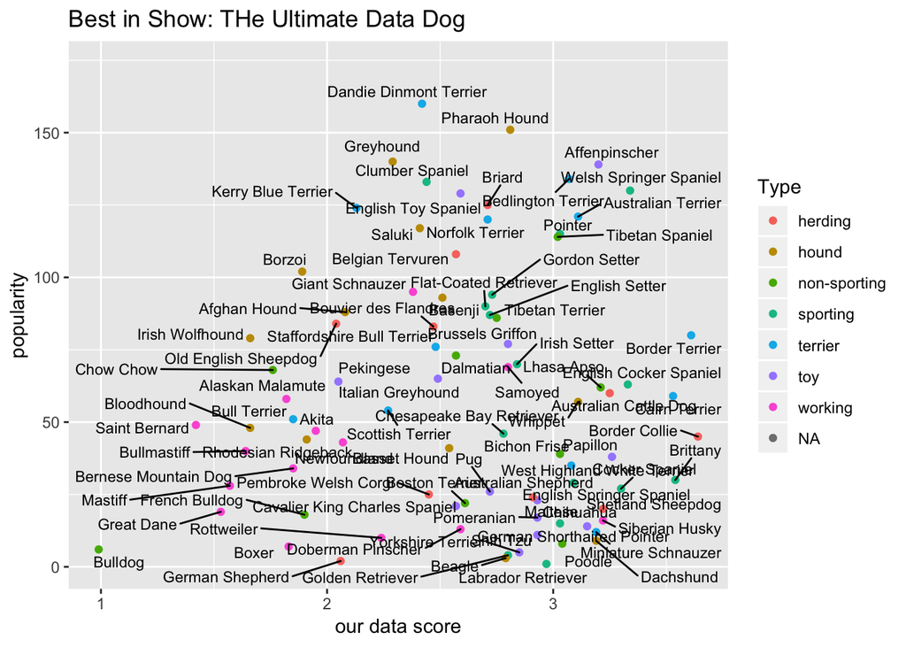

```r
ggplot(tdog, aes(x=Score, y=Popularity, label=Breed)) +
  geom_point(aes(color=Type)) +
  labs(title = "Best in Show: THe Ultimate Data Dog", x="our data score", y="popularity") +
  geom_text_repel(aes(label=Breed), color="black", size=3)
```